# outbreak.info R package: Genomic data

May 3, 2021

#### **getSeqCounts**

**Description:**

Returns a `dataframe` of number of sequences per day by location

**Usage:**

```r
getSeqCounts(location=NULL, cumulative=NULL, subadmin=NULL)
```

**Arguments:**

location: a location name (if not specified, global total counts returned)

cumulative: `Boolean` (T/F), T returns cumulative number of sequences to date

subadmin: `Boolean` (T/F), subadmin=T and cumulative=T returns cumulative number of sequences for next administrative level

**Example:**

```r
df=getSeqCounts(location="United States")
print(head(df))
```

```
##         date total_count
## 1 2020-01-27           1
## 2 2020-01-28           1
## 3 2020-01-29           4
## 4 2020-01-31           1
## 5 2020-02-06           1
## 6 2020-02-08           1
```

#### **getGlobalPrevalence**

**Description:**

Returns a `dataframe` of global daily prevalence of a PANGO lineage

**Usage:**

```r
getGlobalPrevalence(pangolin_lineage, mutations=NULL, cumulative=NULL)
```

**Arguments:**

pangolin_lineage: PANGO lineage name

mutations: a `vector` of mutation(s)

cumulative: `Boolean` (T/F), T returns cumulative global prevalence since first day of detection

**Example:**

```r
df=getGlobalPrevalence(pangolin_lineage = "B.1.1.7", mutations = "S:E484K")
print(head(df))
```

```
##         date total_count lineage_count total_count_rolling
## 1 2020-12-17        3787             1            3787.000
## 2 2020-12-18        3850             1            3818.500
## 3 2020-12-19        2520             0            3385.667
## 4 2020-12-20        2427             0            3146.000
## 5 2020-12-21        7297             0            3976.200
## 6 2020-12-22        3152             0            3838.833
##   lineage_count_rolling   proportion proportion_ci_lower proportion_ci_upper
## 1             1.0000000 2.640613e-04        2.849306e-05        0.0012335956
## 2             1.0000000 2.618829e-04        2.826170e-05        0.0012235850
## 3             0.6666667 1.969085e-04        3.186766e-05        0.0013795989
## 4             0.5000000 1.589320e-04        1.560698e-07        0.0007980741
## 5             0.4000000 1.005986e-04        1.234919e-07        0.0006315372
## 6             0.3333333 8.683194e-05        1.278986e-07        0.0006540656
```

#### **getPrevalenceByLocation**

**Description:**

Returns a `dataframe` of daily prevalence of a PANGO lineage by location

**Usage:**

```r
getPrevalenceByLocation(pangolin_lineage, location, mutations=NULL, cumulative=NULL)
```

**Arguments:**

pangolin_lineage: PANGO lineage name

location: a location name

mutations: a `vector` of mutation(s)

cumulative: `Boolean` (T/F), T returns cumulative prevalence since first day of detection

**Example:**

```r
df=getPrevalenceByLocation(pangolin_lineage = "P.1", location = "Brazil")
print(head(df))
```

```
##         date total_count lineage_count total_count_rolling
## 1 2020-11-03          26             1            26.00000
## 2 2020-11-04          24             0            25.00000
## 3 2020-11-05          14             0            21.33333
## 4 2020-11-06           9             0            18.25000
## 5 2020-11-07           2             0            15.00000
## 6 2020-11-08           1             0            12.66667
##   lineage_count_rolling proportion proportion_ci_lower proportion_ci_upper
## 1             1.0000000 0.03846154        4.181775e-03          0.16603456
## 2             0.5000000 0.02000000        1.944577e-05          0.09468276
## 3             0.3333333 0.01562500        2.310564e-05          0.11147032
## 4             0.2500000 0.01369863        2.690312e-05          0.12855821
## 5             0.2000000 0.01333333        3.219414e-05          0.15181666
## 6             0.1666667 0.01315789        3.705193e-05          0.17261945
```

#### **plotPrevalenceByLocation**

**Description:**

Plot the daily prevalence of a PANGO lineage by location

**Usage:**

```r
plotPrevalenceByLocation(pangolin_lineage, location, mutations=NULL, cumulative=NULL)
```

**Arguments:**

pangolin_lineage: PANGO lineage name

location: a location name

mutations: a `vector` of mutation(s)

cumulative: `Boolean` (T/F), T returns cumulative prevalence since first day of detection

**Example:**

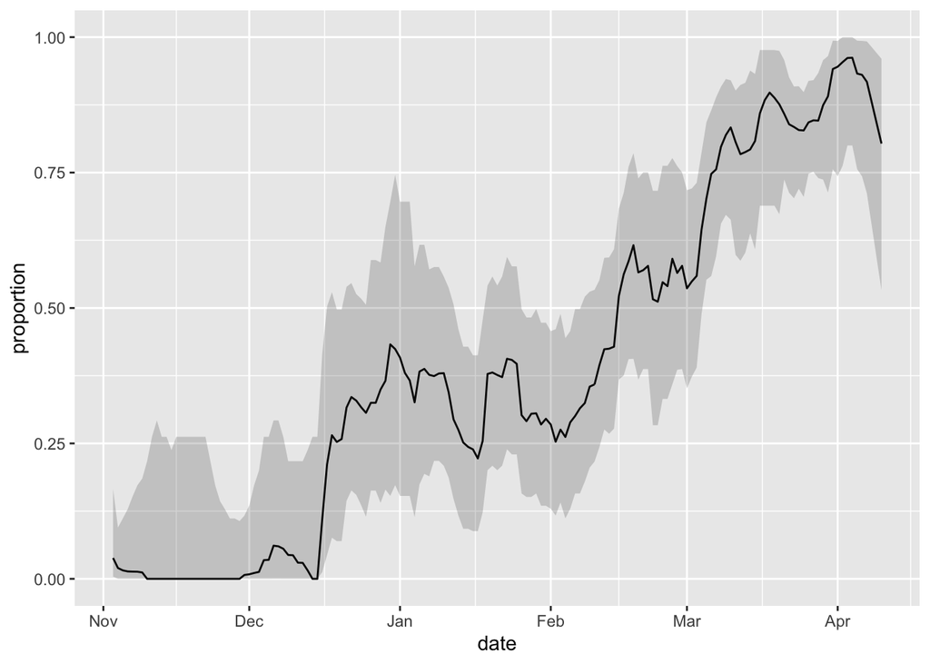

```r
p=plotPrevalenceByLocation(pangolin_lineage = "P.1", location = "Brazil")
show(p)
```

#### **getCumulativeBySubadmin**

**Description:**

Returns a `dataframe` of the cumulative prevalence of a PANGO lineage by the immediate administrative level of a specified location

**Usage:**

```r
getCumulativeBySubadmin(pangolin_lineage, location=NULL, mutations=NULL, ndays=NULL)
```

**Arguments:**

pangolin_lineage: PANGO lineage name

location: a location name (if not specified, cumulative prevalence at the country level globally returned)

mutations: a `vector` of mutation(s)

ndays: an `integer` specifying number of days from current date to calculative cumuative counts (if not specified, no limit on window)

**Example:**

```r
df=getCumulativeBySubadmin(pangolin_lineage="B.1.1.7", location="California")
print(head(df))
```

```
##          date                            name              id total_count
## 24 2020-10-29 Napa Solano Yolo Marin Counties  USA_US-CA_None           6
## 17 2020-12-16                        Mariposa USA_US-CA_06043           2
## 15 2020-12-17                          Madera USA_US-CA_06039          16
## 25 2020-12-18                          Nevada USA_US-CA_06057           4
## 47 2020-12-18                          Tehama USA_US-CA_06103           2
## 3  2020-12-21                          Amador USA_US-CA_06005           1
##    lineage_count cum_total_count cum_lineage_count proportion
## 24             0              27                 0          0
## 17             0               2                 0          0
## 15             0             266                 0          0
## 25             0               6                 0          0
## 47             0               3                 0          0
## 3              0               1                 0          0
##    proportion_ci_lower proportion_ci_upper
## 24        1.801870e-05         0.088050832
## 17        2.169085e-04         0.666821754
## 15        1.844259e-06         0.009390152
## 25        7.849985e-05         0.330388909
## 47        1.506360e-04         0.535583243
## 3         3.855810e-04         0.853253684
```

#### **getCollectionDateByLocation**

**Description:**

Returns most recent collection date by location

**Usage:**

```r
getCollectionDateByLocation(pangolin_lineage, location=NULL, mutations=NULL)
```

**Arguments:**

pangolin_lineage: PANGO lineage name

location: a location name (if not specified, collection date at the global level returned)

mutations: a `vector` of mutation(s)

**Example:**

```r
df=getCollectionDateByLocation(pangolin_lineage="B.1.1.7", location="California")
print(head(df))
```

```
##         date date_count
## 1 2021-04-19          7
```

#### **getSubmissionDateByLocation**

**Description:**

Returns most recent submission date by location

**Usage:**

```r
getSubmissionDateByLocation(pangolin_lineage, location=NULL, mutations=NULL)
```

**Arguments:**

pangolin_lineage: PANGO lineage name

location: a location name (if not specified, submission date at the global level returned)

mutations: a `vector` of mutation(s)

**Example:**

```r
df=getSubmissionDateByLocation(pangolin_lineage="B.1.1.7", location="California")
print(head(df))
```

```
##         date date_count
## 1 2021-05-02         16
```

#### **getLag**

**Description:**

Returns the daily lag between collection and submission dates by location

**Usage:**

```r
getLag(location=NULL)
```

**Arguments:**

location: a location name (if not specified, daily lag globally returned)

**Example:**

```r
df=getLag(location="California")
print(head(df))
```

```
##   date_collected date_submitted total_count
## 1     2020-01-27     2020-02-11           1
## 2     2020-01-29     2020-02-07           3
## 3     2020-02-06     2020-02-22           1
## 4     2020-02-10     2020-02-22           1
## 5     2020-02-23     2020-02-27           1
## 6     2020-02-26     2020-04-02           1
```

#### **getMutationDetails**

**Description:**

Returns details of mutation(s)

**Usage:**

```r
getMutationDetails(mutations)
```

**Arguments:**

mutations: a `vector` of mutation(s)

**Example:**

```r
df=getMutationDetails(mutations=c("S:E484K", "S:N501Y"))
print(head(df))
```

```
##           type mutation gene ref_codon   pos alt_codon is_synonymous ref_aa
## 1 substitution  S:N501Y    S       AAT 23062       TAT         False      N
## 2 substitution  S:E484K    S       GAA 23011       AAA         False      E
##   codon_num alt_aa absolute_coords change_length_nt is_frameshift
## 1       501      Y            None             None          None
## 2       484      K            None             None          None
##   deletion_codon_coords
## 1                  None
## 2                  None
```

#### **getMutationAcrossLineage**

**Description:**

Returns prevalence of a mutation across lineages by location

**Usage:**

```r
getMutationAcrossLineage(mutations, location=NULL)
```

**Arguments:**

mutations: a `vector` of mutation(s)

location: a location name (if not specified, prevalence globally returned)

**Example:**

```r
df=getMutationAcrossLineage(mutations="S:N501Y", location="United States")
print(head(df))
```

```
##   pangolin_lineage lineage_count mutation_count   proportion
## 1            b.1.2         72867            971 0.0133256481
## 2          b.1.1.7         71997          69108 0.9598733281
## 3              b.1         31440            798 0.0253816794
## 4          b.1.429         25036              9 0.0003594823
## 5          b.1.526         12629              9 0.0007126455
## 6          b.1.427         10873              3 0.0002759128
##   proportion_ci_lower proportion_ci_upper
## 1        1.251230e-02        0.0141776540
## 2        9.584212e-01        0.9612884437
## 3        2.368657e-02        0.0271641655
## 4        1.778886e-04        0.0006559979
## 5        3.526781e-04        0.0013002620
## 6        7.771534e-05        0.0007361680
```

#### **getMutationsByLineage**

**Description:**

Returns prevalence of all mutations in a lineage above a certain frequency threshold

**Usage:**

```r
getMutationsByLineage(pangolin_lineage, frequency=0.8)
```

**Arguments:**

pangolin_lineage: PANGO lineage name

frequency: a number between 0 and 1 specifying the frequency threshold above which to return mutations

**Example:**

```r
df=getMutationsByLineage(pangolin_lineage="P.1", frequency=0.8)
print(head(df))
```

```
##       mutation mutation_count lineage_count  gene ref_aa alt_aa codon_num
## 1      s:h655y           8756          8805     S      H      Y       655
## 2 orf1a:k1795q           8753          8805 ORF1a      K      Q      1795
## 3      s:d614g           8750          8805     S      D      G       614
## 4 orf1b:e1264d           8709          8805 ORF1b      E      D      1264
## 5  orf3a:s253p           8679          8805 ORF3a      S      P       253
## 6       s:t20n           8670          8805     S      T      N        20
##   codon_end         type prevalence change_length_nt
## 1      None substitution  0.9944350             None
## 2      None substitution  0.9940943             None
## 3      None substitution  0.9937535             None
## 4      None substitution  0.9890971             None
## 5      None substitution  0.9856899             None
## 6      None substitution  0.9846678             None
```

#### **getAllLineagesByLocation**

**Description:**

Returns prevalence of all lineages over time for a specified location

**Usage:**

```r
getAllLineagesByLocation(location, other_threshold=0.05, nday_threshold=10, ndays=180, other_exclude=NULL, cumulative=F)
```

**Arguments:**

location: a location name

other_threshold: minimum prevalence threshold below which lineages are accumulated under “Other”

nday_threshold: minimum number of days in which the prevalence of a lineage must be below other_threshold to be accumulated under “Other”

ndays: the number of days before the current date to be used as a window to accumulate lineages under “Other”

other_exclude: comma separated lineages that are NOT to be included under “Other” even if the conditions specified by the three thresholds above are met

cumulative: `Boolean` (T/F), T returns cumulative prevalence of lineages

**Example:**

```r
df=getAllLineagesByLocation(location = "India", other_threshold=0.03, nday_threshold=60, other_exclude="P.1")
print(head(df))
```

```
##            date total_count lineage_count   lineage prevalence
## 2667 2020-01-27           1             1     other          1
## 2668 2020-01-28           0             0     other          0
## 2119 2020-01-29           1             1 b.1.36.29          1
## 2669 2020-01-29           0             0     other          0
## 2120 2020-01-30           0             0 b.1.36.29          0
## 2670 2020-01-30           0             0     other          0
##      prevalence_rolling
## 2667          1.0000000
## 2668          1.0000000
## 2119          0.7500000
## 2669          0.2500000
## 2120          0.6666667
## 2670          0.3333333
```

#### **getGenomicData**

**Description:**

Retrieve a `dataframe` of up-to-date COVID-19 genomic data from [outbreak.info](https://outbreak.info/) according to user specifications.

**Usage:**

```r
getGenomicData(query_url, location=NULL, cumulative=NULL, pangolin_lineage=NULL, mutations=NULL, ndays=NULL, frequency=NULL, subadmin=NULL, other_threshold=NULL, nday_threshold=NULL, other_exclude=NULL){
```

**Arguments:**

See wrapper functions

**Example:**

```r
df=getGenomicData(query_url="prevalence-by-location", location="United Kingdom", pangolin_lineage = "B.1.1.7")
print(head(df))
```

```
##         date total_count lineage_count total_count_rolling
## 1 2020-09-20         450             1            450.0000
## 2 2020-09-21        1064             1            757.0000
## 3 2020-09-22         562             0            692.0000
## 4 2020-09-23         551             1            656.7500
## 5 2020-09-24        1860             0            897.4000
## 6 2020-09-25         719             0            867.6667
##   lineage_count_rolling   proportion proportion_ci_lower proportion_ci_upper
## 1             1.0000000 0.0022222222        2.398771e-04         0.010339077
## 2             1.0000000 0.0013210040        1.425701e-04         0.006157644
## 3             0.6666667 0.0009633911        1.559657e-04         0.006734292
## 4             0.7500000 0.0011419871        1.642768e-04         0.007091906
## 5             0.6000000 0.0006685982        1.203135e-04         0.005198820
## 6             0.5000000 0.0005762582        5.655449e-07         0.002888929
```